# Data Visualisation

Project I: NHGIS and the US county population

ADJENIA Danélius; SABI DJESSOU Bana nadege; SODJINOU Hippolyte

```r
if(!require(tidyverse))install.packages("tidyverse")
if(!require(gridExtra))install.packages("gridExtra")
if(!require(tmap))install.packages("tmap")
if(!require(sf))install.packages("sf")
if(!require(ipumsr))install.packages("ipumsr")
if(!require(purrr))install.packages("purrr")
if(!require(scales)) install.packages("scales")
if(!require(leaflet)) install.packages("leaflet")
if(!require(shiny)) install.packages("shiny")
if(!require(scales)) install.packages("scales")
```

```r
library(tidyverse)
library(gridExtra)
library(ipumsr)
library(dplyr)
library(purrr)
library(sf)
library(tmap)
library(scales)
library(leaflet)
library(shiny)
library(scales)
```

#

## 1 Preliminaries

US counties’s shapefile

```r
# Set API environnment

mykey <- readLines("ipums_key.txt")

# Save key in .Renviron for use across sessions
set_ipums_api_key(mykey, save = TRUE)
```

```r
# Spaciale file


# "tl": Census Bureau TIGER/Line
nhgis_ext_1 <- define_extract_nhgis(
  description = "County shapefiles (2023)",
  shapefiles = "us_county_2023_tl2023"
)
nhgis_ext_submitted <- submit_extract(nhgis_ext_1)
nhgis_ext_complete <- wait_for_extract(nhgis_ext_submitted)
filepath <- download_extract(nhgis_ext_submitted,
                             download_dir = "C:/Users/sodji/OneDrive/Bureau/Datavis Traning/Datavis traning/Project Dataviz/Data/")
```

```r
# "tl": Census Bureau TIGER/Line
nhgis_ext <- define_extract_nhgis(
  description = "County shapefiles (2020)",
  shapefiles = "us_county_2020_tl2020"
)
```

```r
nhgis_ext_submitted <- submit_extract(nhgis_ext)

nhgis_ext_complete <- wait_for_extract(nhgis_ext_submitted)
```

```r
## Download the dataset
filepath <- download_extract(nhgis_ext_submitted,
                            download_dir = "C:/Users/sodji/OneDrive/Bureau/Datavis Traning/Datavis traning/Project Dataviz/Data/")
```

```r
map_dir <- "C:/Users/sodji/OneDrive/Bureau/Datavis Traning/Datavis traning/Project Dataviz/Data/"
shape_us <- read_ipums_sf(paste0(map_dir,"nhgis0002_shape.zip"))
```

```r
# contiguous states / counties
shape_us %>%
  mutate(STATEFP = as.integer(STATEFP)) %>%
  filter(STATEFP < 57) %>%
  filter(!(STATEFP %in% c(2,15))) ->
  shape_us
```

```r
shape_us # 3,108 x 21
```

```
## Simple feature collection with 3108 features and 20 fields
## Geometry type: MULTIPOLYGON
## Dimension:     XY
## Bounding box:  xmin: -2356114 ymin: -1337505 xmax: 2258244 ymax: 1565791
## Projected CRS: USA_Contiguous_Albers_Equal_Area_Conic
## # A tibble: 3,108 × 21
##    GISJOIN  STATEFP COUNTYFP COUNTYNS GEOID NAME    NAMELSAD LSAD  CLASSFP MTFCC
##  * <chr>      <int> <chr>    <chr>    <chr> <chr>   <chr>    <chr> <chr>   <chr>
##  1 G0100010       1 001      00161526 01001 Autauga Autauga… 06    H1      G4020
##  2 G0100030       1 003      00161527 01003 Baldwin Baldwin… 06    H1      G4020
##  3 G0100050       1 005      00161528 01005 Barbour Barbour… 06    H1      G4020
##  4 G0100070       1 007      00161529 01007 Bibb    Bibb Co… 06    H1      G4020
##  5 G0100090       1 009      00161530 01009 Blount  Blount … 06    H1      G4020
##  6 G0100110       1 011      00161531 01011 Bullock Bullock… 06    H1      G4020
##  7 G0100130       1 013      00161532 01013 Butler  Butler … 06    H1      G4020
##  8 G0100150       1 015      00161533 01015 Calhoun Calhoun… 06    H1      G4020
##  9 G0100170       1 017      00161534 01017 Chambe… Chamber… 06    H1      G4020
## 10 G0100190       1 019      00161535 01019 Cherok… Cheroke… 06    H1      G4020
## # ℹ 3,098 more rows
## # ℹ 11 more variables: CSAFP <chr>, CBSAFP <chr>, METDIVFP <chr>,
## #   FUNCSTAT <chr>, ALAND <dbl>, AWATER <dbl>, INTPTLAT <chr>, INTPTLON <chr>,
## #   Shape_Leng <dbl>, Shape_Area <dbl>, geometry <MULTIPOLYGON [m]>
```

```r
glimpse(shape_us)
```

```
## Rows: 3,108
## Columns: 21
## $ GISJOIN    <chr> "G0100010", "G0100030", "G0100050", "G0100070", "G0100090",…
## $ STATEFP    <int> 1, 1, 1, 1, 1, 1, 1, 1, 1, 1, 1, 1, 1, 1, 1, 1, 1, 1, 1, 1,…
## $ COUNTYFP   <chr> "001", "003", "005", "007", "009", "011", "013", "015", "01…
## $ COUNTYNS   <chr> "00161526", "00161527", "00161528", "00161529", "00161530",…
## $ GEOID      <chr> "01001", "01003", "01005", "01007", "01009", "01011", "0101…
## $ NAME       <chr> "Autauga", "Baldwin", "Barbour", "Bibb", "Blount", "Bullock…
## $ NAMELSAD   <chr> "Autauga County", "Baldwin County", "Barbour County", "Bibb…
## $ LSAD       <chr> "06", "06", "06", "06", "06", "06", "06", "06", "06", "06",…
## $ CLASSFP    <chr> "H1", "H1", "H1", "H1", "H1", "H1", "H1", "H1", "H1", "H1",…
## $ MTFCC      <chr> "G4020", "G4020", "G4020", "G4020", "G4020", "G4020", "G402…
## $ CSAFP      <chr> "388", "380", NA, "142", "142", NA, NA, NA, "122", NA, "142…
## $ CBSAFP     <chr> "33860", "19300", "21640", "13820", "13820", NA, NA, "11500…
## $ METDIVFP   <chr> NA, NA, NA, NA, NA, NA, NA, NA, NA, NA, NA, NA, NA, NA, NA,…
## $ FUNCSTAT   <chr> "A", "A", "A", "A", "A", "A", "A", "A", "A", "A", "A", "A",…
## $ ALAND      <dbl> 1539634184, 4117656199, 2292160149, 1612188717, 1670259090,…
## $ AWATER     <dbl> 25674812, 1132956041, 50523213, 9572303, 14860281, 6030667,…
## $ INTPTLAT   <chr> "+32.5322367", "+30.6592183", "+31.8702531", "+33.0158929",…
## $ INTPTLON   <chr> "-086.6464395", "-087.7460666", "-085.4051035", "-087.12714…
## $ Shape_Leng <dbl> 210512.6, 637811.6, 272036.6, 190851.1, 242282.0, 210654.5,…
## $ Shape_Area <dbl> 1565309074, 4264564259, 2342683550, 1621761112, 1685119450,…
## $ geometry   <MULTIPOLYGON [m]> MULTIPOLYGON (((895625.2 -5..., MULTIPOLYGON (…
```

### NHGIS Time Series data

```r
# Time series tables do not contain individual data tables,
#   but do require a geographic level selection, and allow an optional selection of years

nhgis_ext <- define_extract_nhgis(
  description = "CW8: Persons by Sex by Race at tract level",
  time_series_tables = tst_spec(
    "CW8",
    geog_levels = c("county"),
    years = c("2010", "2000")
 )
)
nhgis_ext_submitted <- submit_extract(nhgis_ext)
nhgis_ext_complete <- wait_for_extract(nhgis_ext_submitted)
filepath <- download_extract(nhgis_ext_submitted,
                             download_dir = "C:/Users/sodji/OneDrive/Bureau/Datavis Traning/Datavis traning/Project Dataviz/Data/")
```

```r
data_by_race <- read_csv(paste0(map_dir,"nhgis0003_csv/nhgis0003_ts_geog2010_county.csv"))
data_by_race %>%
  filter(GEOGYEAR == 2010) ->
  data_by_race
```

```r
glimpse(data_by_race)
```

```
## Rows: 3,143
## Columns: 54
## $ GISJOIN    <chr> "G0100010", "G0100030", "G0100050", "G0100070", "G0100090",…
## $ GEOGYEAR   <dbl> 2010, 2010, 2010, 2010, 2010, 2010, 2010, 2010, 2010, 2010,…
## $ STATE      <chr> "Alabama", "Alabama", "Alabama", "Alabama", "Alabama", "Ala…
## $ STATEA     <chr> "01", "01", "01", "01", "01", "01", "01", "01", "01", "01",…
## $ COUNTY     <chr> "Autauga County", "Baldwin County", "Barbour County", "Bibb…
## $ COUNTYA    <chr> "001", "003", "005", "007", "009", "011", "013", "015", "01…
## $ CW8AA2000  <dbl> 17335.31, 59953.00, 7720.16, 8031.20, 24169.49, 1694.00, 59…
## $ CW8AA2000L <dbl> 17335, 59953, 7720, 7988, 24013, 1694, 5952, 42689, 10717, …
## $ CW8AA2000U <dbl> 17436, 59953, 7724, 8200, 24270, 1694, 5996, 42790, 10745, …
## $ CW8AA2010  <dbl> 21067, 76274, 7027, 8934, 26149, 1554, 5471, 43168, 9815, 1…
## $ CW8AB2000  <dbl> 3447.63, 7047.00, 6790.17, 2584.00, 291.00, 4286.31, 3966.0…
## $ CW8AB2000L <dbl> 3447, 7047, 6790, 2584, 291, 4274, 3966, 9529, 6378, 639, 2…
## $ CW8AB2000U <dbl> 3524, 7047, 6796, 2585, 291, 4303, 3970, 9530, 6380, 639, 2…
```

[output cut: 41 more lines]

```r
data_by_race <- data_by_race %>%
  mutate(
    pop_white   = CW8AA2010 + CW8AG2010,
    pop_black   = CW8AB2010 + CW8AH2010,
    pop_native  = CW8AC2010 + CW8AI2010, # American Indian and Alaska Native
    pop_asian   = CW8AD2010 + CW8AJ2010, # Asian and Pacific Islander
    pop_two_more= CW8AF2010 + CW8AL2010, #Two or More Races
    pop_other   = CW8AE2010 + CW8AK2010, # Other Race
    total_pop   = pop_white + pop_black + pop_native + pop_asian + pop_two_more + pop_other
  )
```

Description:  
CW8AA2010: 2010: Persons: Male ~ White (single race)  
CW8AG2010: 2010: Persons: Female ~ White (single race)  
CW8AB2010: 2010: Persons: Male ~ Black or African American (single race)  
CW8AH2010: 2010: Persons: Female ~ Black or African American (single race)  
CW8AC2010: 2010: Persons: Male ~ American Indian and Alaska Native (single race)  
CW8AI2010: 2010: Persons: Female ~ American Indian and Alaska Native (single race)  
CW8AD2010: 2010: Persons: Male ~ Asian and Pacific Islander (single race)  
CW8AJ2010: 2010: Persons: Female ~ Asian and Pacific Islander (single race)  
CW8AE2010: 2010: Persons: Male ~ Some Other Race (single race)  
CW8AK2010: 2010: Persons: Female ~ Some Other Race (single race)  
CW8AF2010: 2010: Persons: Male ~ Two or More Races  
CW8AL2010: 2010: Persons: Female ~ Two or More Races

```r
glimpse(data_by_race)
```

```
## Rows: 3,143
## Columns: 61
## $ GISJOIN      <chr> "G0100010", "G0100030", "G0100050", "G0100070", "G0100090…
## $ GEOGYEAR     <dbl> 2010, 2010, 2010, 2010, 2010, 2010, 2010, 2010, 2010, 201…
## $ STATE        <chr> "Alabama", "Alabama", "Alabama", "Alabama", "Alabama", "A…
## $ STATEA       <chr> "01", "01", "01", "01", "01", "01", "01", "01", "01", "01…
## $ COUNTY       <chr> "Autauga County", "Baldwin County", "Barbour County", "Bi…
## $ COUNTYA      <chr> "001", "003", "005", "007", "009", "011", "013", "015", "…
## $ CW8AA2000    <dbl> 17335.31, 59953.00, 7720.16, 8031.20, 24169.49, 1694.00, …
## $ CW8AA2000L   <dbl> 17335, 59953, 7720, 7988, 24013, 1694, 5952, 42689, 10717…
## $ CW8AA2000U   <dbl> 17436, 59953, 7724, 8200, 24270, 1694, 5996, 42790, 10745…
## $ CW8AA2010    <dbl> 21067, 76274, 7027, 8934, 26149, 1554, 5471, 43168, 9815,…
## $ CW8AB2000    <dbl> 3447.63, 7047.00, 6790.17, 2584.00, 291.00, 4286.31, 3966…
## $ CW8AB2000L   <dbl> 3447, 7047, 6790, 2584, 291, 4274, 3966, 9529, 6378, 639,…
## $ CW8AB2000U   <dbl> 3524, 7047, 6796, 2585, 291, 4303, 3970, 9530, 6380, 639,…
```

[output cut: 48 more lines]

```r
data_by_race <- data_by_race %>%
  select(
    GISJOIN,GEOGYEAR,STATE,
    (ncol(data_by_race) - 6):ncol(data_by_race)   # Select the last 7 columns
  )
```

```r
# Perform the spatial join
shape_us_pop_2010 <- shape_us %>%
  left_join(data_by_race, by = "GISJOIN")
```

```r
glimpse(shape_us_pop_2010)
```

```
## Rows: 3,108
## Columns: 30
## $ GISJOIN      <chr> "G0100010", "G0100030", "G0100050", "G0100070", "G0100090…
## $ STATEFP      <int> 1, 1, 1, 1, 1, 1, 1, 1, 1, 1, 1, 1, 1, 1, 1, 1, 1, 1, 1, …
## $ COUNTYFP     <chr> "001", "003", "005", "007", "009", "011", "013", "015", "…
## $ COUNTYNS     <chr> "00161526", "00161527", "00161528", "00161529", "00161530…
## $ GEOID        <chr> "01001", "01003", "01005", "01007", "01009", "01011", "01…
## $ NAME         <chr> "Autauga", "Baldwin", "Barbour", "Bibb", "Blount", "Bullo…
## $ NAMELSAD     <chr> "Autauga County", "Baldwin County", "Barbour County", "Bi…
## $ LSAD         <chr> "06", "06", "06", "06", "06", "06", "06", "06", "06", "06…
## $ CLASSFP      <chr> "H1", "H1", "H1", "H1", "H1", "H1", "H1", "H1", "H1", "H1…
## $ MTFCC        <chr> "G4020", "G4020", "G4020", "G4020", "G4020", "G4020", "G4…
## $ CSAFP        <chr> "388", "380", NA, "142", "142", NA, NA, NA, "122", NA, "1…
## $ CBSAFP       <chr> "33860", "19300", "21640", "13820", "13820", NA, NA, "115…
## $ METDIVFP     <chr> NA, NA, NA, NA, NA, NA, NA, NA, NA, NA, NA, NA, NA, NA, N…
```

[output cut: 17 more lines]

#

## 2 County population barplots

```r
#write_csv(shape_us_pop_2010, file=paste0(map_dir,"shape_us_pop_2010.csv"))
```

```r
# Filter to keep only Los Angeles County
la_data <- shape_us_pop_2010 %>%
  filter(NAMELSAD == "Los Angeles County")
```

```r
la_long <- la_data %>%
  select(pop_other, pop_native, pop_black,  pop_asian, pop_white, pop_two_more, total_pop) %>%
  pivot_longer(
    cols = c(pop_other, pop_native, pop_two_more, pop_black, pop_asian, pop_white),
    names_to = "race",
    values_to = "population"
  ) %>%
  # Calculate the share of each breed in the total population
  mutate(
    share = population / total_pop[1]   # [1] Because total_pop is the same for each line
  )
```

```r
## Dataframe that contain the race name

data_race_name <- data.frame(
  race = c("pop_other", "pop_two_more", "pop_native" , "pop_black", "pop_asian", "pop_white"),
  race_name = c("other race", "two or more race", "native race", "black race", "asian race", "white race"))
```

```r
data_race_name
```

```
##           race        race_name
## 1    pop_other       other race
## 2 pop_two_more two or more race
## 3   pop_native      native race
## 4    pop_black       black race
## 5    pop_asian       asian race
## 6    pop_white       white race
```

```r
## Merge the la_long with data_race_name

la_long_race <- left_join(la_long, data_race_name, by = c("race"))
la_long_race
```

```
## Simple feature collection with 6 features and 5 fields
## Geometry type: MULTIPOLYGON
## Dimension:     XY
## Bounding box:  xmin: -2082285 ymin: -280626.4 xmax: -1948802 ymax: -51338.92
## Projected CRS: USA_Contiguous_Albers_Equal_Area_Conic
## # A tibble: 6 × 6
##   total_pop                          geometry race  population   share race_name
##       <dbl>                <MULTIPOLYGON [m]> <chr>      <dbl>   <dbl> <chr>
## 1   9818605 (((-2068639 -280608.5, -2068649 … pop_…    2140632 0.218   other ra…
## 2   9818605 (((-2068639 -280608.5, -2068649 … pop_…      72828 0.00742 native r…
## 3   9818605 (((-2068639 -280608.5, -2068649 … pop_…     438713 0.0447  two or m…
## 4   9818605 (((-2068639 -280608.5, -2068649 … pop_…     856874 0.0873  black ra…
## 5   9818605 (((-2068639 -280608.5, -2068649 … pop_…    1372959 0.140   asian ra…
## 6   9818605 (((-2068639 -280608.5, -2068649 … pop_…    4936599 0.503   white ra…
```

```r
# Set the desired order for the variable "race_name"
la_long_race <- la_long_race %>%
  mutate(race_name = factor(race_name,
                            levels = c("white race","asian race", "black race", "two or more race", "native race", "other race")))
```

```r
# Create the chart
p1 <- ggplot(la_long_race, aes(x = race_name, y = population, fill = race_name)) +
  geom_col() +
  # Labels, axes & title
  labs(
    title = "county: Los Angeles",
    x = NULL,
    y = "population"
  ) +
  # Manual Color Palette
  scale_fill_manual(values = c(
    "white race"  = "#f46f63", # salmon
    "asian race"  = "#00b85b", # green
    "black race"  = "#af9f10", # brown/olive
    "two or more race" = "green", # darkgreen
    "native race" = "#0096b2", # blue
    "other race"  = "#ea65f5"  # rose
  )) +
  coord_flip() +
  # Clean theme + no caption
  theme_bw() +
  theme(
    axis.title.y = element_blank(),
    axis.text.y = element_blank(),
    panel.grid.major.x = element_line(color = "grey70", linewidth = 0.1), # Major vertical lines
    panel.grid.minor.x = element_line(color = "grey90", linewidth = 0.1), # Minor vertical lines
    panel.grid.major.y = element_line(color = "grey70", linewidth = 0.1),
    panel.grid.minor.y = element_line(color = "grey90", linewidth = 0.1),
    legend.position = "none"
  ) +
  geom_text(aes(y = 80000, x = race_name, label = race_name, hjust = 0), color = "black", size = 5) # add the text
```

```r
p2 <- ggplot(la_long_race, aes(x = race_name, y = share, fill = race_name)) +
  geom_col() +
  # Labels, axes & title
  labs(
    title = "",
    x = NULL,
    y = "population share"
  ) +
  # Manual Color Palette
  scale_fill_manual(values = c(
    "white race"  = "#f46f63", # salmon
    "asian race"  = "#00b85b", # green
    "black race"  = "#af9f10", # brown/olive
    "two or more race" = "green", # darkgreen
    "native race" = "#0096b2", # blue
    "other race"  = "#ea65f5"  # rose
  )) +
  scale_y_continuous(labels = percent) +
  coord_flip() +
  # Clean theme + no caption
  theme_bw() +
  theme(
    axis.title.y = element_blank(),
    axis.text.y = element_blank(),
    panel.grid.major.x = element_line(color = "grey70", linewidth = 0.1),
    panel.grid.minor.x = element_line(color = "grey90", linewidth = 0.1),
    panel.grid.major.y = element_line(color = "grey70", linewidth = 0.1),
    panel.grid.minor.y = element_line(color = "grey90", linewidth = 0.1),
    legend.position = "none"
  ) +
  geom_text(aes(y = 0.05, x = race_name, label = sprintf("%.2f%%", share * 100), hjust = 0, vjust = 0.5), color = "black", size = 5) # add percentage
```

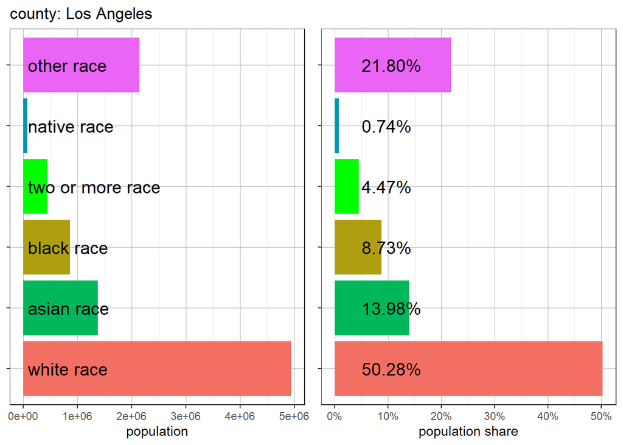

```r
# Side-by-side display
grid.arrange(p1, p2, ncol = 2)
```

## 3 All counties

Map for all counties for the total population count

```r
map <- tm_shape(shape_us_pop_2010, projection = 2163) +
  tm_polygons("total_pop", border.col = "gray50",
              border.alpha = .5,palette = "YlOrBr", title = "",
              style = "quantile", n = 8,showNA = TRUE) +
  tm_layout(title = "Total population by County",
            title.position = c("center", "top"),
            legend.position = c("left", "bottom"),
            frame = FALSE,
            legend.text.size = 0.6,
            legend.title.size = 0.8,
            inner.margins = c(0.1, 0.1, 0.05, 0.05))
```

```
## ── tmap v3 code detected ───────────────────────────────────────────────────────
```

[output not shown]

[output not shown]

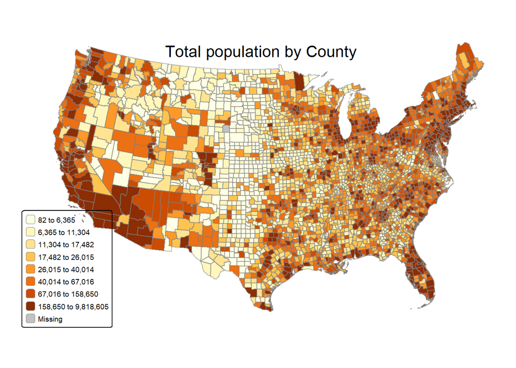

```r
map
```

The map shows the distribution of population by county in the United States, with a color gradient from light beige (lowest populations, 82 to 6,365 people) to dark brown (highest populations, 158,650 to 9,818,605 people). It can be seen that the most populous counties are concentrated mainly on the East and West coasts, in the Northeast, in Florida and around the major metropolitan areas, while the Great Plains and some mountainous areas of the West have significantly less dense populations.

## 4 leaflet

```r
# Extract dataset for state
body_request <- define_extract_nhgis(
  description = "State shapefiles (2020)",
  shapefiles = "us_state_2020_tl2020"
)


nhgis_ext_submitted <- submit_extract(body_request)

nhgis_ext_complete <- wait_for_extract(nhgis_ext_submitted)


## Download the dataset
filepath <- download_extract(nhgis_ext_submitted,
                            download_dir = "C:/Users/sodji/OneDrive/Bureau/Datavis Traning/Datavis traning/Project Dataviz/Data/")
```

```r
# Upload data for US state
shape_us_state <- read_ipums_sf(paste0(map_dir,"nhgis0004_shape.zip"))
```

```r
glimpse(shape_us_state)
```

```
## Rows: 52
## Columns: 18
## $ GISJOIN    <chr> "G010", "G020", "G040", "G050", "G060", "G080", "G090", "G1…
## $ REGION     <chr> "3", "4", "4", "3", "4", "4", "1", "3", "3", "3", "3", "4",…
## $ DIVISION   <chr> "6", "9", "8", "7", "9", "8", "1", "5", "5", "5", "5", "9",…
## $ STATEFP    <chr> "01", "02", "04", "05", "06", "08", "09", "10", "11", "12",…
## $ STATENS    <chr> "01779775", "01785533", "01779777", "00068085", "01779778",…
## $ GEOID      <chr> "01", "02", "04", "05", "06", "08", "09", "10", "11", "12",…
## $ STUSPS     <chr> "AL", "AK", "AZ", "AR", "CA", "CO", "CT", "DE", "DC", "FL",…
## $ NAME       <chr> "Alabama", "Alaska", "Arizona", "Arkansas", "California", "…
## $ LSAD       <chr> "00", "00", "00", "00", "00", "00", "00", "00", "00", "00",…
## $ MTFCC      <chr> "G4000", "G4000", "G4000", "G4000", "G4000", "G4000", "G400…
## $ FUNCSTAT   <chr> "A", "A", "A", "A", "A", "A", "A", "A", "A", "A", "A", "A",…
## $ ALAND      <dbl> 1.311755e+11, 1.478941e+12, 2.943610e+11, 1.346609e+11, 4.0…
## $ AWATER     <dbl> 4591915034, 245380162784, 858853288, 3121867339, 2029413383…
## $ INTPTLAT   <chr> "+32.7396323", "+63.3473560", "+34.2039362", "+34.8955256",…
## $ INTPTLON   <chr> "-086.8434593", "-152.8397334", "-111.6063449", "-092.44462…
## $ Shape_Leng <dbl> 2307842.6, 69216981.0, 2396748.8, 2197977.2, 6018144.8, 210…
## $ Shape_Area <dbl> 1.337837e+11, 1.508699e+12, 2.952199e+11, 1.377827e+11, 4.0…
## $ geometry   <MULTIPOLYGON [m]> MULTIPOLYGON (((763205.4 -7..., MULTIPOLYGON (…
```

```r
# 1. (Optionnel) Filtrer certains États (ici, on retire AK, HI et PR)
shape_us_state_f <- shape_us_state %>%
  filter(!STUSPS %in% c("AK", "HI", "PR"))

# 2. Agréger la géométrie des comtés par État
us_states <- shape_us_state_f %>%
  group_by(NAME) %>%
  summarise(
    GISJOIN  = first(GISJOIN),
    geometry = st_union(geometry)
  )
```

```r
# contiguous states (exclude: Alaska, Hawaii)
#us_states %>%
 # mutate(STATEFP = as.integer(STATEFP)) %>%
  #filter(STATEFP < 57) %>%
  #filter(!(STATEFP %in% c(2,15))) ->
  #us_states

us_states <- us_states %>%
  st_make_valid()

us_states <- sf::st_transform(us_states, 4326)
us_states %>%
  sf::st_centroid() ->
  us_state_centroids
shape_us_pop_2010_la <- st_transform(shape_us_pop_2010, 4326)
```

```r
# Define the color palette for the total population using quantiles
pal_fun <- colorQuantile(
  palette = "YlOrRd",
  domain = shape_us_pop_2010_la$total_pop,
  n = 8  # Number of quantile classes
)

# Set the popup for counties
p_popup <- paste0(
  "<strong>County: </strong>", shape_us_pop_2010_la$NAME, "<br>",
  "<strong>Total Population: </strong>", shape_us_pop_2010_la$total_pop,"<br>",
    "<strong>County ID: </strong>", shape_us_pop_2010_la$GEOID )
```

```r
# Create the Leaflet Map
us_los_angeles <- leaflet(shape_us_pop_2010_la) %>%
  addPolygons(
    stroke = TRUE, color = "black", opacity = 0.2, weight = 2,
    fillColor = ~ pal_fun(total_pop),
    fillOpacity = 1, smoothFactor = 0.5,
    label  = ~ NAME,
    fill   = TRUE,
    popup = p_popup,
    group = "County"
  ) %>%
  # Add caption
  addLegend(
    position = "bottomright",
    pal = pal_fun,
    values = ~total_pop,  # Only use the 'total_pop' column here
    title = "Total Population",
    opacity = 0.8
  )%>%

  # Layer control to toggle the display
  addLayersControl(
    overlayGroups = c("County", "State"),
    options = layersControlOptions(collapsed = FALSE)
  )
```

[figure not shown]

```r
# View Map
us_los_angeles
```

## Task 4: Shiny

```r
 counties_WGS84 <- sf::st_transform(shape_us_pop_2010, 4326)
```

```r
ui <- fluidPage(
  titlePanel("US county population in 2010"),
  sidebarLayout(
    sidebarPanel(
      uiOutput("select_state"),
      uiOutput("counties_in_state")
    ),
    mainPanel(
      leafletOutput("map"),
      textOutput("text"),
      plotOutput("BarPlot")
    )
  )
)

server <- function(input, output) {

  # State Selection
  output$select_state <- renderUI({
    selectInput(
      inputId = "select_state",
      label = "State:",
      choices = unique(counties_WGS84$STATE),
      selected = 1
    )
  })

  # County Selection in this State
  output$counties_in_state <- renderUI({
    req(input$select_state)
    selectInput(
      inputId = "select_county",
      label = "County:",
      choices = sort(unique(counties_WGS84$NAME[counties_WGS84$STATE == input$select_state]))
    )
  })

  # The bar plot
  output$BarPlot <- renderPlot({

    req(input$select_county)

    # Filter by selected county
    # Switch to long format
    # Aggregate (sum) to avoid duplication (only one line per race)
    temp_lo <- counties_WGS84 %>%
      filter(NAME == input$select_county) %>%
      select(GEOID, GEOGYEAR, NAME, starts_with("pop")) %>%
      pivot_longer(
        cols = c(pop_other, pop_native, pop_two_more, pop_black, pop_asian, pop_white),
        names_to = "race",
        values_to = "population"
      ) %>%
      group_by(race) %>%
      summarise(population = sum(population), .groups = "drop") %>%
      mutate(share = population / sum(population))

    # Breed -> race_name Lookup Table
    data_race_name_state <- data.frame(
      race = c("pop_other", "pop_two_more", "pop_native", "pop_black", "pop_asian", "pop_white"),
      race_name = c("other race", "two or more race", "native race", "black race", "asian race", "white race")
    )

    # Join to get the variable race_name and reorder
    plot_data <- left_join(temp_lo, data_race_name_state, by = "race") %>%
      mutate(
        race_name = factor(
          race_name,
          levels = c("white race", "asian race", "black race",
                     "two or more race", "native race", "other race")
        )
      )

    # First bar plot
    p1 <- ggplot(plot_data, aes(x = race_name, y = population, fill = race_name)) +
      geom_col() +
      labs(
        title = paste0("County: ", input$select_county),
        x = NULL,
        y = "Population"
      ) +
      scale_fill_manual(values = c(
        "white race"       = "#f46f63",
        "asian race"       = "#00b85b",
        "black race"       = "#af9f10",
        "two or more race" = "green",
        "native race"      = "#0096b2",
        "other race"       = "#ea65f5"
      )) +
      coord_flip() +
      theme_bw() +
      theme(
        axis.title.y = element_blank(),
        axis.text.y  = element_blank(),
        panel.grid.major.x = element_line(color = "grey70", linewidth = 0.1),
        panel.grid.minor.x = element_line(color = "grey90", linewidth = 0.1),
        panel.grid.major.y = element_line(color = "grey70", linewidth = 0.1),
        panel.grid.minor.y = element_line(color = "grey90", linewidth = 0.1),
        legend.position = "none"
      ) +
      geom_text(
        aes(
          x = race_name,
          y = 0.05 * max(population),
          label = race_name
        ),
        color = "black",
        size = 5,
        hjust = 0   # Aligns the text to the left of this point
      )

    # Second bar plot : part (pourcentage)
    p2 <- ggplot(plot_data, aes(x = race_name, y = share, fill = race_name)) +
      geom_col() +
      labs(
        title = "",
        x = NULL,
        y = "Population share"
      ) +
      scale_fill_manual(values = c(
        "white race"       = "#f46f63",
        "asian race"       = "#00b85b",
        "black race"       = "#af9f10",
        "two or more race" = "green",
        "native race"      = "#0096b2",
        "other race"       = "#ea65f5"
      )) +
      scale_y_continuous(labels = scales::percent) +
      coord_flip() +
      theme_bw() +
      theme(
        axis.title.y = element_blank(),
        axis.text.y  = element_blank(),
        panel.grid.major.x = element_line(color = "grey70", linewidth = 0.1),
        panel.grid.minor.x = element_line(color = "grey90", linewidth = 0.1),
        panel.grid.major.y = element_line(color = "grey70", linewidth = 0.1),
        panel.grid.minor.y = element_line(color = "grey90", linewidth = 0.1),
        legend.position = "none"
      ) +
      geom_text(
        aes(
          x = race_name,
          y = 0.05 * max(share),
          label = scales::percent(share)
        ),
        color = "black",
        size = 5,
        hjust = 0
      )

    gridExtra::grid.arrange(p1, p2, nrow = 1)
  })

   output$map <- renderLeaflet({
    bks <- mapsf::mf_get_breaks(counties_WGS84$total_pop, nbreaks = 7, breaks = "quantile")
    pal_fun <- colorQuantile("YlOrRd", NULL, n = 7)
    p_popup <- paste0("<strong>Total Population: </strong>", counties_WGS84$total_pop,"<br>",
                      "<strong>County ID: </strong>", counties_WGS84$GEOID,"<br>",
                      "<strong>County: </strong>", counties_WGS84$NAME,"<br>",
                      "<strong>State: </strong>", counties_WGS84$STATE)

    leaflet() %>%
      #addPolygons(data=us_states$geometry,
                  #label = us_states$NAME,
                 # stroke = TRUE, color="black", opacity=.2,weight=2,
                  #group = "state") %>%
      addPolygons(data=counties_WGS84,
                  stroke = TRUE, color = "black", opacity = 0.2, weight = 2,
                  fillColor = ~pal_fun(total_pop),
                  fillOpacity = 0.8, smoothFactor = 0.5,
                  popup = p_popup,
                  group = "county",
                  layerId = counties_WGS84$GEOID)%>%
      addLabelOnlyMarkers(data = us_state_centroids$geometry,
                          label = us_state_centroids$NAME,
                          labelOptions = labelOptions(noHide = TRUE,
                                                      direction = 'top', textOnly = TRUE),
                          group = "NAME") %>%
      addLegend("bottomright",
                colors = RColorBrewer::brewer.pal(7, "YlOrRd"),
                labels = paste0("up to ", format(bks[-1], digits = 2)),
                title = 'Total Pop.') %>%
      addLayersControl(overlayGroups = c("state"),baseGroups = c("county"))
  })

  observeEvent(input$map_shape_click, {
    output$text <- renderText({paste0("county id: ",input$map_shape_click$id) })
    # print(input$map_shape_click$id)
    updateSelectInput(inputId = "select_county",
          choices=counties_WGS84$NAME[counties_WGS84$GEOID == input$map_shape_click$id])
  })
}
```

```r
shinyApp(ui, server)
```

[figure not shown]

## Session Information

```r
if (!require(sessioninfo)) install.packages("sessioninfo")
library(sessioninfo)
```

```r
platform_info()
```

```
##  setting  value
##  version  R version 4.4.1 (2024-06-14 ucrt)
##  os       Windows 11 x64 (build 26100)
##  system   x86_64, mingw32
##  ui       RTerm
##  language (EN)
##  collate  French_France.utf8
##  ctype    French_France.utf8
##  tz       Europe/Paris
##  date     2025-04-10
##  pandoc   3.6.4 @ C:/PROGRA~1/Pandoc/ (via rmarkdown)
```